# Analyse des Correspondances Multiples

Jeu de données poison

Ce jeu de données contient 55 individus et 22 variables.

### 1. Observation d’individus extrêmes

L’analyse des graphes ne révèle aucun individu singulier.

### 2. Distribution de l’inertie

L’inertie des axes factoriels indique d’une part si les variables sont structurées et suggère d’autre part le nombre judicieux de composantes principales à étudier.

Les 2 premiers axes de l’ ACM expriment **46.44%** de l’inertie totale du jeu de données ; cela signifie que 46.44% de la variabilité totale du nuage des individus (ou des variables) est représentée dans ce plan. C’est un pourcentage relativement moyen, et le premier plan représente donc seulement une part de la variabilité contenue dans l’ensemble du jeu de données actif. Cette valeur est supérieure à la valeur référence de **33.27%**, la variabilité expliquée par ce plan est donc significative (cette intertie de référence est le quantile 0.95 de la distribution des pourcentages d’inertie obtenus en simulant 864 jeux de données aléatoires de dimensions comparables sur la base d’une distribution uniforme).

Du fait de ces observations, il serait alors probablement nécessaire de considérer également les dimensions supérieures ou égales à la troisième dans l’analyse.

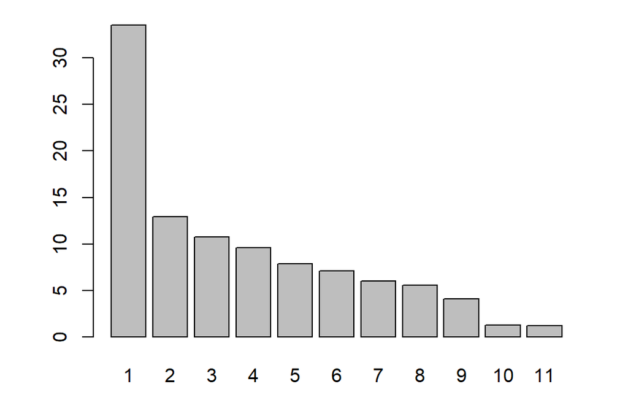

**Figure 2 - Decomposition of the total inertia on the components of the ACM**

Une estimation du nombre pertinent d’axes à interpréter suggère de restreindre l’analyse à la description des 1 premiers axes. Ces composantes révèlent un taux d’inertie supérieur à celle du quantile 0.95 de distributions aléatoires (33.52% contre 18.44%). Cette observation suggère que seul cet axe est porteur d’une véritable information. En conséquence, la description de l’analyse sera restreinte à ces seuls axes.

### 3. Description de la dimension 1

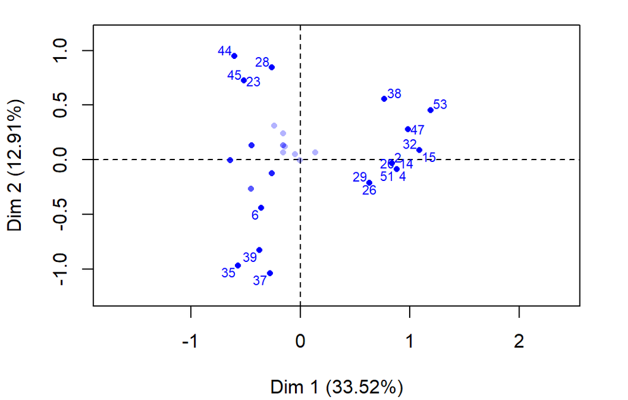

**Figure 3.1 - Graphe des individus (ACM)** *Les individus libellés sont ceux ayant la plus grande contribution à la construction du plan.*

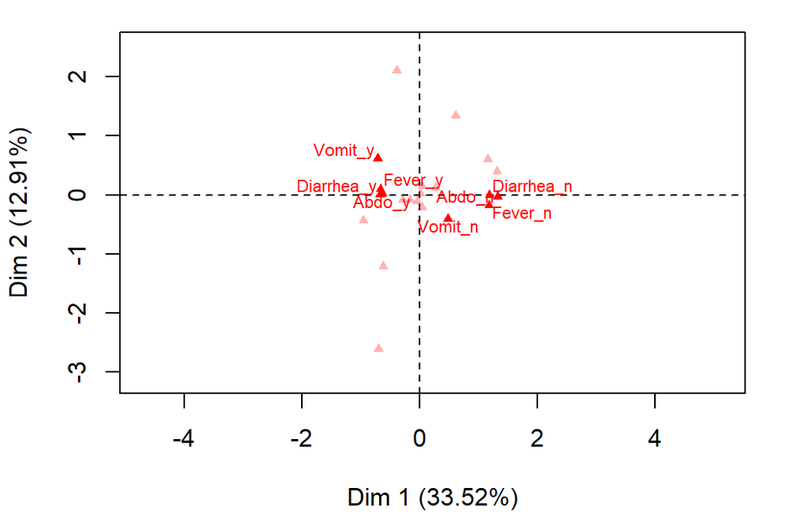

**Figure 3.2 - Graphe des variables (ACM)** *Les variables libellées sont celles les mieux représentées sur le plan.*

Le groupe auquel les individus *4*, *14*, *20*, *51*, *26*, *29* et *2* appartiennent (caractérisés par une coordonnée positive sur l’axe) partage :

- une forte fréquence des modalités *Diarrhae=Diarrhea_n*, *Abdominals=Abdo_n*, *Fever=Fever_n*, *Vomiting=Vomit_n* et *Nausea=Nausea_n* (du plus commun au plus rare).
- une faible fréquence des modalités *Abdominals=Abdo_y*, *Diarrhae=Diarrhea_y*, *Fever=Fever_y*, *Vomiting=Vomit_y* et *Nausea=Nausea_y* (du plus rare au plus commun).

Le groupe auquel les individus *32*, *15*, *53* et *47* appartiennent (caractérisés par une coordonnée positive sur l’axe) partage :

- une forte fréquence des modalités *Cheese=Cheese_n*, *Mayo=Mayo_n*, *Icecream=Icecream_n*, *Diarrhae=Diarrhea_n* et *Abdominals=Abdo_n* (du plus commun au plus rare).
- une faible fréquence des modalités *Cheese=Cheese_y*, *Mayo=Mayo_y*, *Icecream=Icecream_y*, *Abdominals=Abdo_y* et *Diarrhae=Diarrhea_y* (du plus rare au plus commun).

Le groupe 3 (caractérisés par une coordonnées négative sur l’axe) partage :

- une forte fréquence des modalités *Vomiting=Vomit_y*, *Fever=Fever_y*, *Diarrhae=Diarrhea_y*, *Abdominals=Abdo_y*, *Mayo=Mayo_y* et *Nausea=Nausea_y* (du plus commun au plus rare).
- une faible fréquence des modalités *Vomiting=Vomit_n*, *Fever=Fever_n*, *Abdominals=Abdo_n*, *Diarrhae=Diarrhea_n*, *Mayo=Mayo_n* et *Nausea=Nausea_n* (du plus rare au plus commun).

Le groupe auquel les individus *23*, *45* et *28* appartiennent (caractérisés par une coordonnées négative sur l’axe) partage :

- high frequency for the variable *Courgette=Courg_n*.
- low frequency for the variable *Courgette=Courg_y*.

### 4. Classification

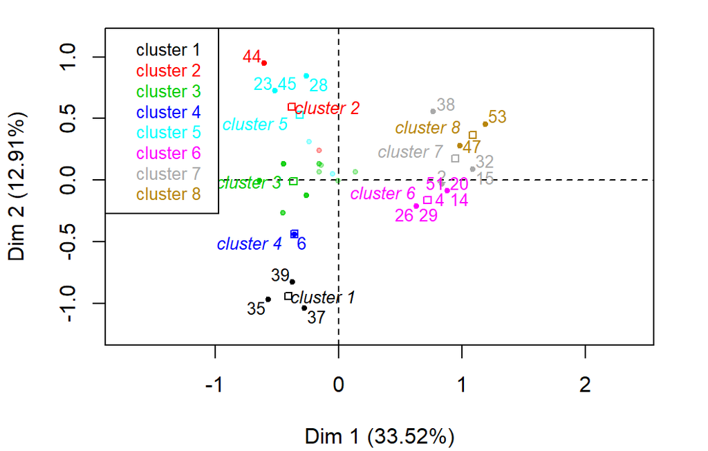

**Figure 4 - Classification Ascendante Hiérachique des individus.** *La classification réalisée sur les individus fait apparaître 8 clusters.*

La classe 3 est composé d’individus partageant :

- une forte fréquence des modalités *Abdominals=Abdo_y*, *Fever=Fever_y*, *Diarrhae=Diarrhea_y*, *Vomiting=Vomit_y*, *Cheese=Cheese_y*, *Mayo=Mayo_y* et *Courgette=Courg_y* (du plus commun au plus rare).
- une faible fréquence des modalités *Abdominals=Abdo_n*, *Fever=Fever_n*, *Diarrhae=Diarrhea_n*, *Vomiting=Vomit_n*, *Cheese=Cheese_n*, *Mayo=Mayo_n* et *Courgette=Courg_n* (du plus rare au plus commun).

- une forte fréquence des modalités *Abdominals=Abdo_n*, *Diarrhae=Diarrhea_n*, *Fever=Fever_n*, *Vomiting=Vomit_n* et *Nausea=Nausea_n* (du plus commun au plus rare).
- une faible fréquence des modalités *Abdominals=Abdo_y*, *Fever=Fever_y*, *Diarrhae=Diarrhea_y*, *Vomiting=Vomit_y* et *Nausea=Nausea_y* (du plus rare au plus commun).

- une forte fréquence des modalités *Cheese=Cheese_n*, *Abdominals=Abdo_n*, *Diarrhae=Diarrhea_n* et *Fever=Fever_n* (du plus commun au plus rare).
- une faible fréquence des modalités *Cheese=Cheese_y*, *Abdominals=Abdo_y*, *Fever=Fever_y* et *Diarrhae=Diarrhea_y* (du plus rare au plus commun).

- une forte fréquence des modalités *Icecream=Icecream_n* et *Mayo=Mayo_n* (du plus commun au plus rare).
- une faible fréquence des modalités *Icecream=Icecream_y* et *Mayo=Mayo_y* (du plus rare au plus commun).

## Annexes

```r
dimdesc(res, axes = 1:1)
```

```
$`Dim 1`
$`Dim 1`$quali
                  R2      p.value
Abdominals 0.8451157 4.055640e-23
Diarrhae   0.7994680 3.910776e-20
Fever      0.7846788 2.600566e-19
Mayo       0.3829749 4.756234e-07
Vomiting   0.3442016 2.510738e-06
Nausea     0.2562007 8.062777e-05
Cheese     0.1944181 7.534834e-04

$`Dim 1`$category
             Estimate      p.value
Abdo_n      0.5671866 4.055640e-23
Diarrhea_n  0.5380920 3.910776e-20
Fever_n     0.5330918 2.600566e-19
Mayo_n      0.4644981 4.756234e-07
Vomit_n     0.3466915 2.510738e-06
Nausea_n    0.3547892 8.062777e-05
Cheese_n    0.3830043 7.534834e-04
Cheese_y   -0.3830043 7.534834e-04
Nausea_y   -0.3547892 8.062777e-05
Vomit_y    -0.3466915 2.510738e-06
Mayo_y     -0.4644981 4.756234e-07
Fever_y    -0.5330918 2.600566e-19
Diarrhea_y -0.5380920 3.910776e-20
Abdo_y     -0.5671866 4.055640e-23
```

**Figure 5 - Liste des variables caractéristiques des dimensions de l’analyse.**

```r
res.hcpc$desc.var
```

```
$test.chi2
                p.value df
Potato     1.490907e-09  7
Fish       1.490907e-09  7
Icecream   1.490907e-09  7
Abdominals 1.088195e-08  7
Fever      2.029003e-07  7
Diarrhae   2.698788e-07  7
Cheese     1.439823e-06  7
Courgette  6.563033e-04  7
Vomiting   1.481791e-03  7
Mayo       7.254002e-03  7

$category
$category$`1`
                Cla/Mod Mod/Cla    Global      p.value    v.test
Potato=Potato_n     100     100  5.454545 3.811702e-05  4.118607
Potato=Potato_y       0       0 94.545455 3.811702e-05 -4.118607

$category$`2`
                    Cla/Mod Mod/Cla    Global     p.value   v.test
Icecream=Icecream_n      50     100  7.272727 0.004040404  2.87499
Icecream=Icecream_y       0       0 92.727273 0.004040404 -2.87499

$category$`3`
                      Cla/Mod    Mod/Cla    Global      p.value    v.test
Abdominals=Abdo_y   70.270270  96.296296 67.272727 4.206346e-06  4.600917
Fever=Fever_y       71.428571  92.592593 63.636364 9.871351e-06  4.419972
Diarrhae=Diarrhea_y 68.571429  88.888889 63.636364 1.433629e-04  3.802293
Vomiting=Vomit_y    77.272727  62.962963 40.000000 7.966135e-04  3.353969
Cheese=Cheese_y     56.250000 100.000000 87.272727 5.834787e-03  2.756924
Mayo=Mayo_y         57.777778  96.296296 81.818182 7.273242e-03  2.684067
Courgette=Courg_y   54.000000 100.000000 90.909091 2.825144e-02  2.193777
Courgette=Courg_n    0.000000   0.000000  9.090909 2.825144e-02 -2.193777
Mayo=Mayo_n         10.000000   3.703704 18.181818 7.273242e-03 -2.684067
Cheese=Cheese_n      0.000000   0.000000 12.727273 5.834787e-03 -2.756924
Vomiting=Vomit_n    30.303030  37.037037 60.000000 7.966135e-04 -3.353969
Diarrhae=Diarrhea_n 15.000000  11.111111 36.363636 1.433629e-04 -3.802293
Fever=Fever_n       10.000000   7.407407 36.363636 9.871351e-06 -4.419972
Abdominals=Abdo_n    5.555556   3.703704 32.727273 4.206346e-06 -4.600917
```

[output cut: 30 more lines]

```
Diarrhae=Diarrhea_y  0.00000       0 63.63636 0.0142059199 -2.452014
Fever=Fever_y        0.00000       0 63.63636 0.0142059199 -2.452014
Abdominals=Abdo_y    0.00000       0 67.27273 0.0089721599 -2.613113
Cheese=Cheese_y      0.00000       0 87.27273 0.0001026227 -3.884306

$category$`8`
                    Cla/Mod Mod/Cla    Global     p.value    v.test
Icecream=Icecream_n      50     100  7.272727 0.004040404  2.874990
Mayo=Mayo_n              20     100 18.181818 0.030303030  2.166107
Mayo=Mayo_y               0       0 81.818182 0.030303030 -2.166107
Icecream=Icecream_y       0       0 92.727273 0.004040404 -2.874990


attr(,"class")
[1] "catdes" "list "
```

**Figure 6 - Liste des variables caractéristiques des clusters de la classification.**